# MICB425_Project1

version April 24, 2018

### Project_1

#### Introduction

Oxygen minimum zones (OMZs) are areas in the ocean where dissolved oxygen concentrations fall below 20 $\mu$M (1). Due to temperature increases and other effects caused by global warming, OMZs are expanding at a notable rate. Saanich Inlet, a seasonally anoxic fjord off the coast of British Columbia, is a model ecosystem for studying the diversity and biochemical responses of microbial communities to the hypoxic environments commonly observed in OMZs (1, 2). In particular, Saanich Inlet has been used to model the metabolic coupling and symbiotic interactions that occur in OMZs (3). The inlet undergoes recurring cycles of water column stratification and deep water renewal, rendering it a model ecosystem for studying microbial responses to changes in ocean deoxygenation levels (4). Increased levels of primary productivity in ocean surfaces during the spring season, as well as the limited mixing which occurs between the basin and surface waters both result in the development of an anoxic body of water with increasing depth in the Inlet (2). These anoxic regions become populated with chemolithoautotrophs, and eventually lead to a decrease in aerobically respiring organisms found deeper within these zones. Past studies have demonstrated that these kinds of metabolic shifts generally lead to a loss of nitrogen along with the production of greenhouse gases, most notably methane (CH<sub>4</sub>) and nitrous oxide (N<sub>2</sub>O) (1).

In order to investigate the changes that occur in these OMZs, water samples of various depths were collected from Saanich Inlet. Genomic DNA was extracted from these to conduct a metagenomics study, allowing to overcome the barrier of uncultivability of these samples and enable a more thorough exploration of the relationship which exists between the microbes and their communities based on genetic distribution of metabolic processes (5, 6, 7, 8). The extracted DNA is sequenced to generate raw data, which can then be assembled into contiguous sequences. These contigs generated by amplicon sequencing are then compared to a sequence database to determine the microbial taxa present in the environment at each water depth. This involves processing the sequencing data, and there currently exists two methods for this type of data analysis: operational taxonomic units (OTUs) and amplicon sequence variants (ASVs). OTU based pipelines work based on clustering reads which differ by less than a fixed dissimilarity threshold (9). This allows more data to be kept, although some may not be representative of the actual taxa in the community. On the contrary, ASV based pipelines resolve these sequence variants by inferring biological sequences in the sample prior to amplification and possible sequencing errors, and are able to distinguish variants which differ by even one nucleotide (9). This treats each ASV as individual species, though has the potential to discard more data and bias towards sequences that are less error-prone.

The objective of this paper is to analyze the data generated from both OTU and ASV pipelines in order to decide which produces more logical inferences, and ultimately determining which pipeline would be preferred to carry out future analysis of collected water samples. The taxonomy of interest which was selected for this comparison was the phylum Cyanobacteria. Cyanobacteria was selected as there are sufficient numbers of OTUs and ASVs to make sound comparisons, but not so much so that computation-wise it would be infeasible.

#### Methods

##### Sampling

Samples were obtained on Saanich Inlet Cruise 72 and taken from seven major depths spanning the oxycline: 10, 100, 120, 135, 150, 165 and 200 m. Waters were filtered, and genomic DNA was extracted. Further sampling details can be found in (3).

##### DNA Sequencing

Samples were PCR amplified using the 515F and 808R primers, then sequenced according to the standard operating protocol on an Illumina MiSeq platform with Phred33 quality scores.

##### Data Processing

Sequences were processed using either mothur or QIIME2 as follows:

*Mothur Pipeline*: mothur was used to clean-up the data. In brief, paired end reads were combined into contigs using their overlapping regions. Low quality sequences, useless sequence data, chimeric sequences and singletons were removed. OTUs were then determined at 97% similarity. OTUs were classified using the SILVA databases, and the taxonomies for each OTU were condensed. The OTU table, taxonomy data and sample metadata were subsequently cleaned up and combined into a phyloseq object.

*QIIME2 Pipeline*: Demultiplexed sequences were imported into QIIME as manifest reads. QIIME was used to clean up the data along with ASV determination in one step. Sequence quality was visually evaluated, and sequence quality trimming was conducted. All other trimming/filtering parameters were left as default. ASV determination was completed using the Dada2 protocol. ASV classification was completed using the Silva version 119 database at 99% similarity. The ASV table, taxonomy data and sample metadata were subsequently cleaned up and combined into a phyloseq object.

##### Data Analysis

The aforementioned phyloseq objects were imported into R version 3.4.3 (Windows) or 1.1.383 (Mac). The tidyverse, phyloseq, magrittr, knitr and cowplot packages were loaded and used to complete the data analysis. Data was piped into linear models and ANOVA tests to determine statistical significance at the 95% confidence level.

###### Environment setup and Data Cleaning

```
## You set `rngseed` to FALSE. Make sure you've set & recorded
##  the random seed of your session for reproducibility.
## See `?set.seed`
```

```
## ...
```

```
## 614OTUs were removed because they are no longer
## present in any sample after random subsampling
```

```
## ...
```

```
## You set `rngseed` to FALSE. Make sure you've set & recorded
##  the random seed of your session for reproducibility.
## See `?set.seed`
```

```
## ...
```

```
## 6OTUs were removed because they are no longer
## present in any sample after random subsampling
```

```
## ...
```

#### Results

1. How does microbial community structure change with depth and oxygen concentration?

**Alpha-diversity comparison:**  
*Mothur*  
As shown in Figure 1, alpha-diversity by Shannon’s diversity index based on mothur shows an overall decreasing trend as depth increases. Specifically, a stable trend is observed from depths of 0-100m, starts decreasing at 100-150m and stabilizes at 150-200m. Figure 1 also shows an overall increasing trend as oxygen increases. Specifically, Shannon’s diversity index increases from 2.3-4.25 at oxygen concentrations of 0-40$\mu$M and decreases from 4.25-3.9 at oxygen concentrations of 40-220$\mu$M. It was also observed that Shannon’s diversity index is higher in oxic conditions (3.84 ± 0.45) than anoxic conditions (2.39 ± 0.07).

*QIIME2*  
The trends of Shannon’s diversity index across depth and oxygen based on QIIME2 data are similar to those of mothur data. However, QIIME2 pipeline produces higher Shannon’s diversity index than mothur does. Shannon’s diversity index increases from 2.9-5.2 at oxygen concentrations of 0-40$\mu$M and decreases from 5.2-5.1 at oxygen concentrations of 40-200$\mu$M. Figure 2 shows that Shannon’s diversity index is higher in oxic conditions (4.80 ± 0.43) than anoxic conditions (3.15 ± 0.18).

###### Alpha-diversity of mothur data

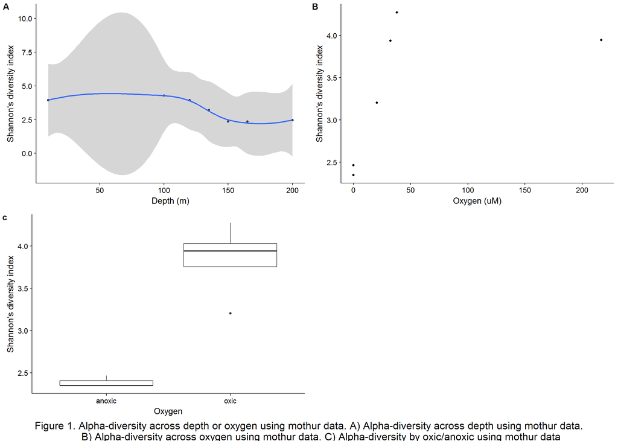

Table 1. Average and standard deviation of alpha-diversity by oxic/anoxic with mothur data

| Statistic | Oxic | Anoxic |
| --- | --- | --- |
| Average | 3.8401008 | 2.3884700 |
| Standard deviation | 0.4523233 | 0.0666717 |

###### Alpha-diversity of QIIME2 data

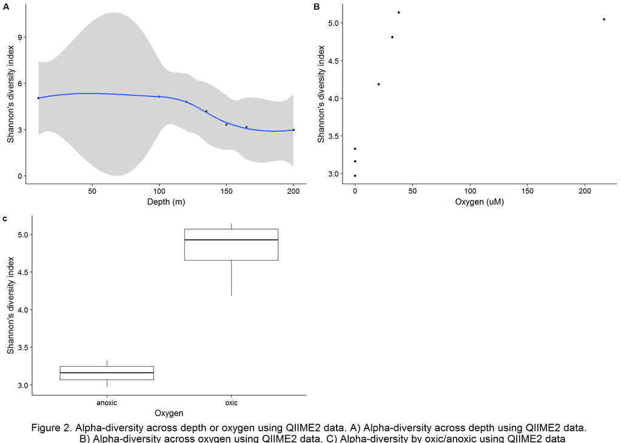

Table 2. Average and standard deviation of alpha-diversity by oxic/anoxic with QIIME2 data

| Statistic | Oxic | Anoxic |
| --- | --- | --- |
| Average | 4.7959464 | 3.1546427 |
| Standard deviation | 0.4296851 | 0.1784873 |

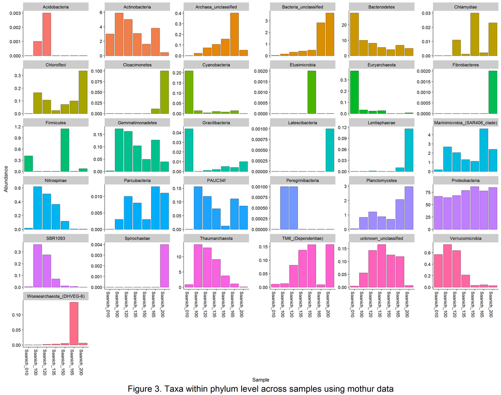

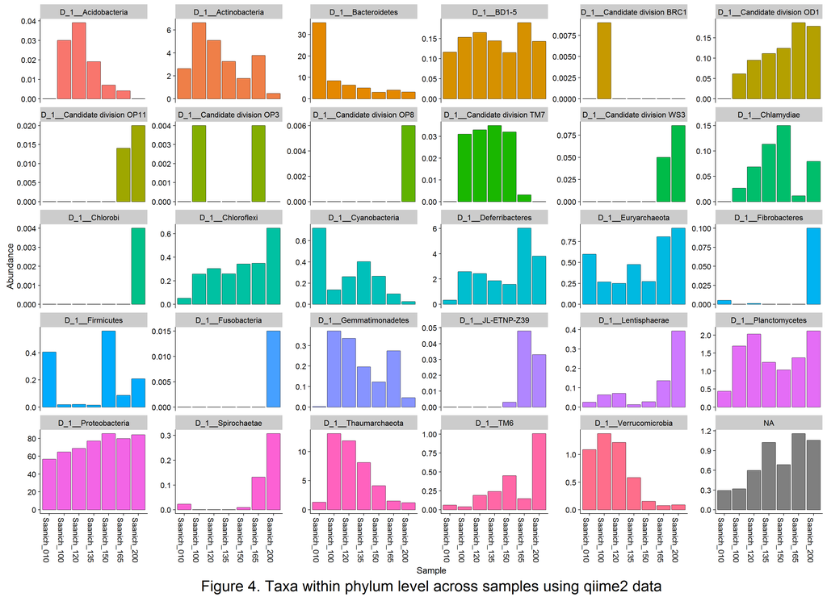

2. Does your taxon of interest significantly differ in abundance with depth and/or oxygen concentration?

*Mothur*  
The difference in cyanobacteria abundance within depth or oxygen was estimated by the linear model using mothur processed data. The statistical results show that abundance of cyanobacteria is significantly different with depth (p = 0.01263) and oxygen (p = 0.00012). However linear models in Figure 5 indicate completely distinct trends of cyanobacteria abundance across depth and oxygen, where there is a decrease in abundance as depth increases and an increase in abundance as oxygen concentrations increases respectively.

*QIIME2*  
For data processed by QIIME2 pipeline, ANOVA tests indicate cyanobacteria abundance in the seven samples has significantly difference across depth (p = 0.014) and oxygen (p = 0.013).The linear models in Figure 6 reveal that cyanobacteria abundance decreases at deeper water or in the environment with insufficient oxygen.

```
##
## Call:
## lm(formula = Abundance ~ Depth_m, data = .)
##
## Residuals:
##       1       2       6       4       5       3       7
##  46.352 -50.700  20.041 -16.609  -3.284 -39.933  44.132
##
## Coefficients:
##             Estimate Std. Error t value Pr(>|t|)
## (Intercept) 173.5309    39.3958   4.405  0.00699 **
## Depth_m      -1.0883     0.2864  -3.800  0.01263 *
## ---
## Signif. codes:  0 '***' 0.001 '**' 0.01 '*' 0.05 '.' 0.1 ' ' 1
##
## Residual standard error: 42.31 on 5 degrees of freedom
## Multiple R-squared:  0.7428, Adjusted R-squared:  0.6914
## F-statistic: 14.44 on 1 and 5 DF,  p-value: 0.01263
```

```
##
## Call:
## lm(formula = Abundance ~ O2_uM, data = .)
##
## Residuals:
##       1       2       6       4       5       3       7
##   6.768 -17.048  19.375  -4.217  12.375 -22.627   5.375
##
## Coefficients:
##             Estimate Std. Error t value Pr(>|t|)
## (Intercept)  -5.3745     7.4690   -0.72 0.504007
## O2_uM         0.9582     0.0885   10.83 0.000117 ***
## ---
## Signif. codes:  0 '***' 0.001 '**' 0.01 '*' 0.05 '.' 0.1 ' ' 1
##
## Residual standard error: 16.87 on 5 degrees of freedom
## Multiple R-squared:  0.9591, Adjusted R-squared:  0.9509
## F-statistic: 117.2 on 1 and 5 DF,  p-value: 0.0001167
```

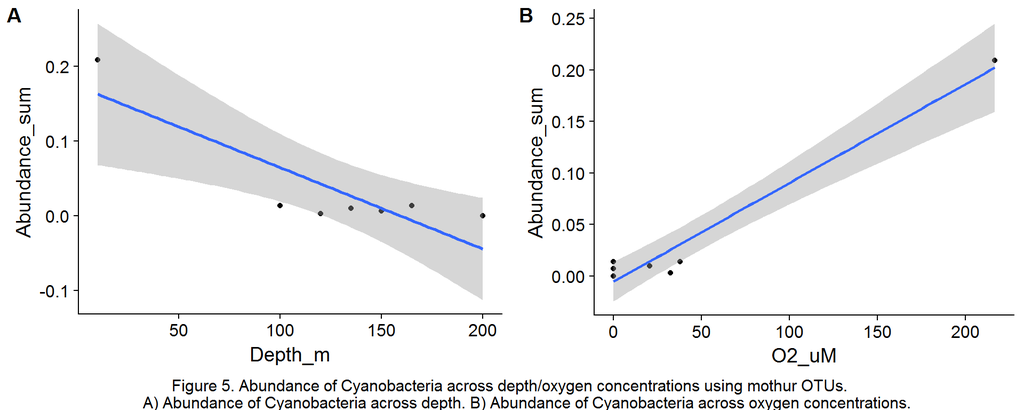

```
##
## Call:
## lm(formula = Abundance ~ Depth_m, data = .)
##
## Residuals:
##        1        4        5        3        2        6        7
##   63.270  160.404   72.980  -30.172 -221.273  -44.444   -0.766
##
## Coefficients:
##             Estimate Std. Error t value Pr(>|t|)
## (Intercept) 687.7807   122.7658   5.602   0.0025 **
## Depth_m      -3.3051     0.8925  -3.703   0.0140 *
## ---
## Signif. codes:  0 '***' 0.001 '**' 0.01 '*' 0.05 '.' 0.1 ' ' 1
##
## Residual standard error: 131.8 on 5 degrees of freedom
## Multiple R-squared:  0.7328, Adjusted R-squared:  0.6794
## F-statistic: 13.71 on 1 and 5 DF,  p-value: 0.01395
```

```
##
## Call:
## lm(formula = Abundance ~ O2_uM, data = .)
##
## Residuals:
##         1         4         5         3         2         6         7
##    0.5171  190.2269  105.9213   18.5371 -121.0450  -61.0787 -133.0787
##
## Coefficients:
##             Estimate Std. Error t value Pr(>|t|)
## (Intercept) 159.0787    57.3201   2.775   0.0391 *
## O2_uM         2.5772     0.6792   3.794   0.0127 *
## ---
## Signif. codes:  0 '***' 0.001 '**' 0.01 '*' 0.05 '.' 0.1 ' ' 1
##
## Residual standard error: 129.5 on 5 degrees of freedom
## Multiple R-squared:  0.7422, Adjusted R-squared:  0.6907
## F-statistic:  14.4 on 1 and 5 DF,  p-value: 0.0127
```

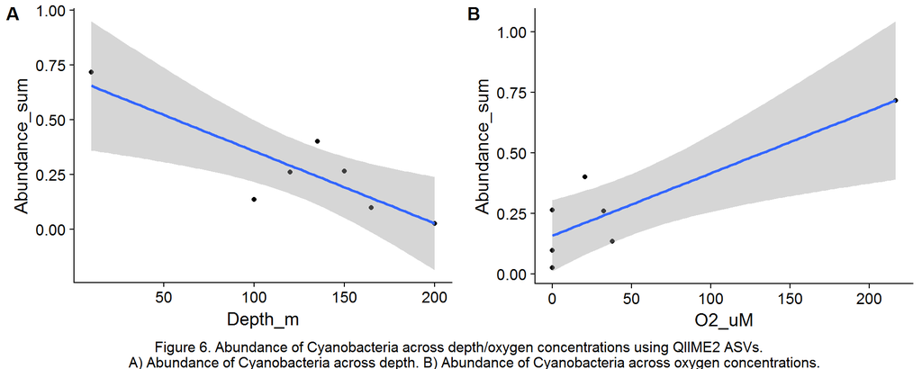

3. Within your taxon, what is the richness (number of OTUs/ASVs)?

*Mothur*  
Across all samples, there are 15 OTUs within cyanobacteria phylum. Table 3 presents the numbers of OTUs within cyanobacteria phylum for each sample. Most of samples contain 3-5 OTUs within cyanobacteria, except Saanich_120 and Saanich_200 which only have 1 and 0 cyanobacteria OTUs respectively.

###### Table showing richness of OTUs using mothur data and ASVs using QIIME2 data

```
## phyloseq-class experiment-level object
## otu_table()   OTU Table:         [ 15 taxa and 7 samples ]
## sample_data() Sample Data:       [ 7 samples by 22 sample variables ]
## tax_table()   Taxonomy Table:    [ 15 taxa by 7 taxonomic ranks ]
```

```
## phyloseq-class experiment-level object
## otu_table()   OTU Table:         [ 51 taxa and 7 samples ]
## sample_data() Sample Data:       [ 7 samples by 22 sample variables ]
## tax_table()   Taxonomy Table:    [ 51 taxa by 7 taxonomic ranks ]
```

```
## Warning in estimate_richness(., measures = c("Observed")): The data you have provided does not have
## any singletons. This is highly suspicious. Results of richness
## estimates (for example) are probably unreliable, or wrong, if you have already
## trimmed low-abundance taxa from the data.
##
## We recommended that you find the un-trimmed data and retry.
```

Table 3. OTUs/ASVs across depth

|  | Depth_m | OTU | ASV |
| --- | --- | --- | --- |
| Saanich_010 | 10 | 5 | 17 |
| Saanich_100 | 100 | 4 | 8 |
| Saanich_120 | 120 | 1 | 15 |
| Saanich_135 | 135 | 4 | 17 |
| Saanich_150 | 150 | 3 | 11 |
| Saanich_165 | 165 | 3 | 5 |
| Saanich_200 | 200 | 0 | 2 |

4. Do the abundances of OTUs/ASVs within your taxon of interest change significantly with depth and/or oxygen concentration?

Using the linear model for statistical interpretation, after correcting the p-value for multiple comparisons, the abundance of OTUs 0189, 0658, 1104, 3852, and 4312 from the mothur pipeline within the cyanobacteria phylum changed significantly with both depth and oxygen. Interestingly, the abundance of ASVs in the QIIME2 pipeline did not have any significant changes across the depth profiles after correcting for the p-value. However, there were 17 ASVs that had a significant abundance change with respect to oxygen concentrations.

###### Mothur

Table 4. Correlation data of Cyanobacteria OTUs with significant differences across depth using mothur data

|  | Estimate | Std. Error | t value | P_value | Adjusted_P |
| --- | --- | --- | --- | --- | --- |
| Otu0189 | -0.9610475 | 0.2669442 | -3.600181 | 0.0155403 | 0.0491962 |
| Otu0658 | -0.0685106 | 0.0190455 | -3.597207 | 0.0155891 | 0.0491962 |
| Otu1104 | -0.0583306 | 0.0164341 | -3.549356 | 0.0163987 | 0.0491962 |
| Otu3852 | -0.0159083 | 0.0044820 | -3.549356 | 0.0163987 | 0.0491962 |
| Otu4312 | -0.0053028 | 0.0014940 | -3.549356 | 0.0163987 | 0.0491962 |

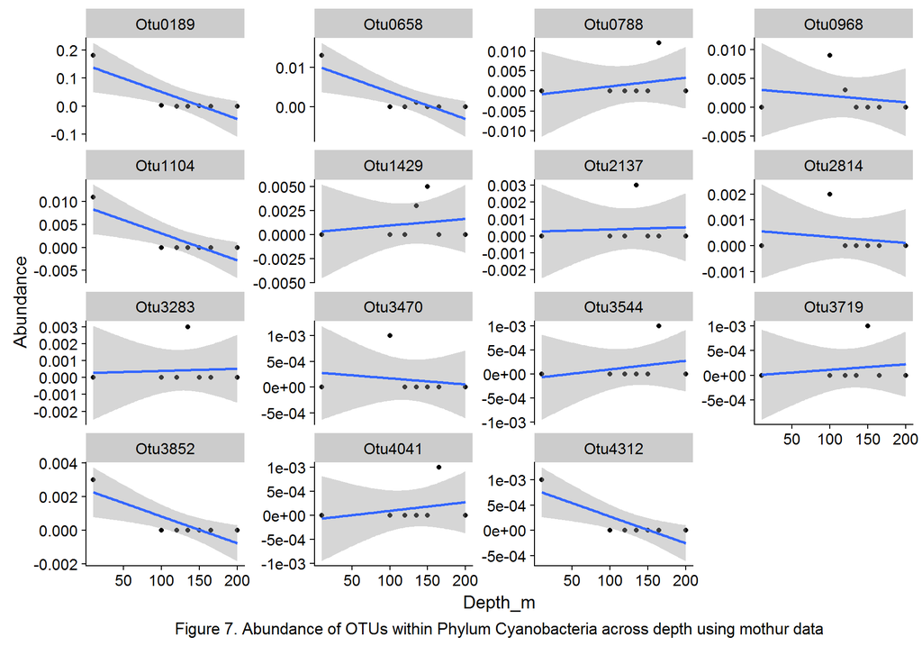

Table 5. Correlation data of Cyanobacteria OTUs with significant differences across oxygen using mothur data

|  | Estimate | Std. Error | t value | P_value | Adjusted_P |
| --- | --- | --- | --- | --- | --- |
| Otu0189 | 0.8586534 | 0.0788686 | 10.88714 | 0.0001136 | 0.0004035 |
| Otu0658 | 0.0611354 | 0.0058159 | 10.51177 | 0.0001345 | 0.0004035 |
| Otu1104 | 0.0522766 | 0.0049096 | 10.64789 | 0.0001264 | 0.0004035 |
| Otu3852 | 0.0142572 | 0.0013390 | 10.64789 | 0.0001264 | 0.0004035 |
| Otu4312 | 0.0047524 | 0.0004463 | 10.64789 | 0.0001264 | 0.0004035 |

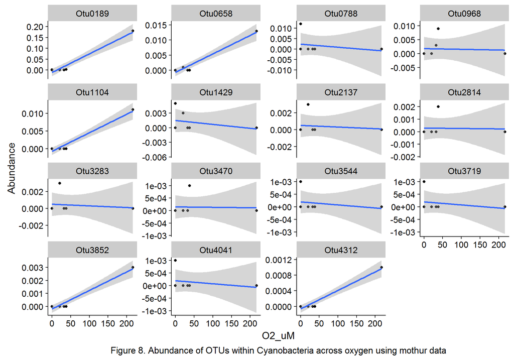

###### QIIME2

```
## [1] "None of ASV has significantly different abundance acrossing depth with QIIME2 data"
```

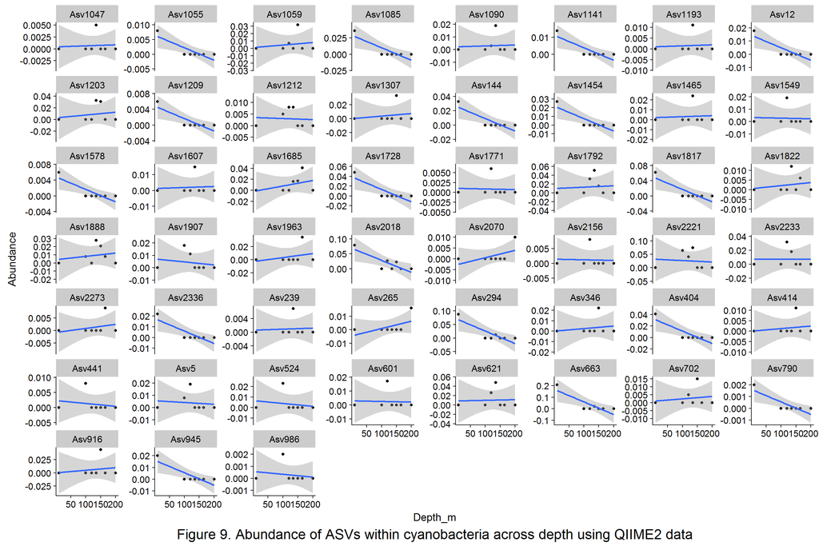

Table 6. Correlation data of Cyanobacteria ASVs with significant differences across oxygen using QIIME2 data

|  | Estimate | Std. Error | t value | P_value | Adjusted_P |
| --- | --- | --- | --- | --- | --- |
| Asv12 | 0.0855435 | 0.0080338 | 10.647891 | 0.0001264 | 0.0004605 |
| Asv144 | 0.1568297 | 0.0147287 | 10.647891 | 0.0001264 | 0.0004605 |
| Asv294 | 0.4104610 | 0.0429693 | 9.552421 | 0.0002128 | 0.0006784 |
| Asv404 | 0.1948490 | 0.0182993 | 10.647891 | 0.0001264 | 0.0004605 |
| Asv663 | 0.9749372 | 0.0956990 | 10.187539 | 0.0001564 | 0.0005316 |
| Asv790 | 0.0095048 | 0.0008926 | 10.647891 | 0.0001264 | 0.0004605 |
| Asv945 | 0.0950483 | 0.0089265 | 10.647891 | 0.0001264 | 0.0004605 |
| Asv1055 | 0.0380193 | 0.0035706 | 10.647891 | 0.0001264 | 0.0004605 |
| Asv1085 | 0.1710870 | 0.0160677 | 10.647891 | 0.0001264 | 0.0004605 |
| Asv1141 | 0.0665338 | 0.0062485 | 10.647891 | 0.0001264 | 0.0004605 |
| Asv1209 | 0.0285145 | 0.0026779 | 10.647891 | 0.0001264 | 0.0004605 |
| Asv1454 | 0.1283152 | 0.0120508 | 10.647891 | 0.0001264 | 0.0004605 |
| Asv1578 | 0.0285145 | 0.0026779 | 10.647891 | 0.0001264 | 0.0004605 |
| Asv1728 | 0.2281160 | 0.0214236 | 10.647891 | 0.0001264 | 0.0004605 |
| Asv1817 | 0.2946498 | 0.0276721 | 10.647891 | 0.0001264 | 0.0004605 |
| Asv2018 | 0.3390505 | 0.0720444 | 4.706133 | 0.0053079 | 0.0159238 |
| Asv2336 | 0.1045531 | 0.0098191 | 10.647891 | 0.0001264 | 0.0004605 |

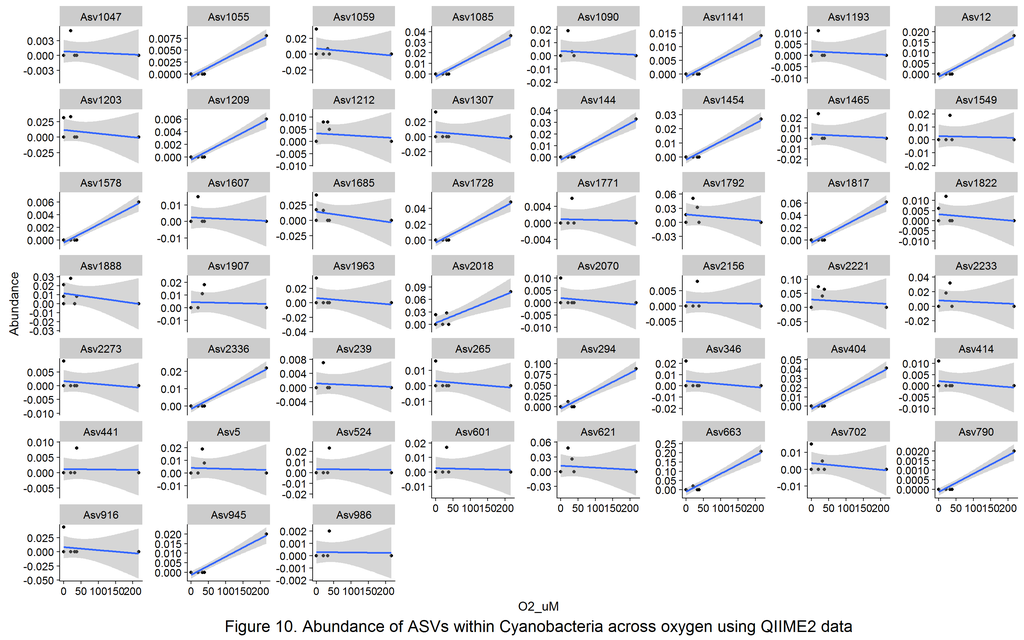

5. Are the answers to the above the same using mothur and QIIME2 processed data?

In terms of differences between the two pipelines, the overall trend between both datasets were similar, however the statistical interpretations of the datasets varied. For starters, the Shannon diversity for the whole microbial community processed with mothur was generally smaller than that estimated by QIIME 2 processed data. Additionally, ANOVA tests indicated that the Shannon diversity had no significant change across depth from the mothur pipeline (p = 0.054). In contrast, there was statistical significance with the Shannon diversity across depth from the QIIME2 dataset (p = 0.022). Within the Cyanobacterial taxon, there were 51 ASVs calculated from the QIIME2 pipeline compared to 15 OTUs from the Mothur pipeline. Interestingly, while there is a difference in the richness between both datasets, 5 of the OTUs had a significantly different abundance with respect to depth and oxygen profiles, while none of the ASVs had a significant change in abundance across depth and 17 ASVs which had a significant difference in abundance across oxygen concentrations. Despite all these variations, the Cyanobacterial taxon itself had a significant difference in abundance with respect to depth and oxygen profiles along the water column across both pipelines.

###### ANOVA on alpha-diversity of mothur data across depth

```
##             Df Sum Sq Mean Sq F value Pr(>F)
## Depth_m      1  2.355  2.3554   6.265 0.0543 .
## Residuals    5  1.880  0.3759
## ---
## Signif. codes:  0 '***' 0.001 '**' 0.01 '*' 0.05 '.' 0.1 ' ' 1
```

###### ANOVA on alpha-diversity of QIIME2 data across depth

```
##             Df Sum Sq Mean Sq F value Pr(>F)
## Depth_m      1  3.563   3.563   10.65 0.0224 *
## Residuals    5  1.673   0.335
## ---
## Signif. codes:  0 '***' 0.001 '**' 0.01 '*' 0.05 '.' 0.1 ' ' 1
```

#### Discussion

Implications of potential differences in pipelines for microbial ecology make it difficult to make conclusive statements in research and discovery, since we become unable to differentiate actual biological differences seen and differences due to a particular pipeline being used. This could also suggest that one pipeline is more suited to the dataset. In fact, this difference could also be exploited, and manipulated so that a pipeline is selected based on the results that it gives, rather than the more appropriate pipeline for the given dataset.

In the context of this project, the main difference between the two pipelines is based on whether the pipeline produces OTUs (mothur) or ASVs (QIIME2). Both of them use different clustering algorithms to determine “true” sequences, and as a result, there are usually far more ASVs in the QIIME2 pipeline than OTUs created with the mothur pipeline. Therefore, when doing downstream analysis of the pipeline results, this may be one of the reasons why there is a large disparity in between the numbers of sequences and quality of the sequences produced even when using the same initial data.

In subsequent analyses with these two pipelines, perhaps a more in-depth analysis of each function available with the phyloseq package should be tested. A dataset of a well-studied and known community could be used so that the output of the functions can be compared with respect to the pipeline used. Comparisons can be made for the outputs of each pipeline, and results from the mothur and QIIME2 pipelines can be assessed with reference to the expected results. Use cases should also be considered, and standard use cases for either pipeline should be indicated so exploitation of pipelines for favourable results does not occur. Mothur may be more suited to a particular dataset, while QIIME2 could be more appropriate for another dataset that should be used with a “denoising” algorithm.

Future directions for this project could possibly involve the analysis of water samples from other OMZs at various depths, along with observation of the Cyanobacteria data present in those samples to see if the relationships are exhibited between oxygen, nitrogen, and the phyla population as with this study. These can also be analyzed once again with both mothur and QIIME2 for further comparison between the pipelines.

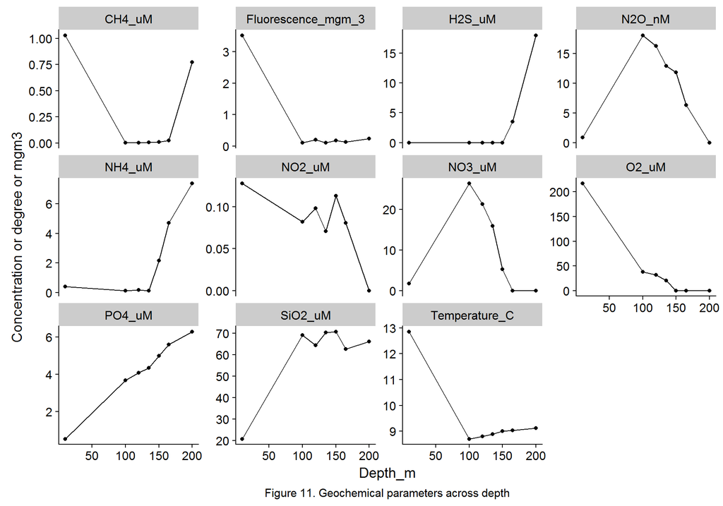

#### References

1. Walsh DA, Zaikova E, Howes CG, Song YC, Wright JJ, Tringe SG, Hallam SJ. 2009. Metagenome of a versatile chemolithoautotroph from expanding oceanic dead zones. Science 326(5952): 578-582.
2. Torres-Beltr?n M, Hawley AK, Capelle D, Zaikova E, Walsh DA., Mueller A, Finke J. 2017. A compendium of geochemical information from the Saanich Inlet water column. Nature scientific data 4(170159).
3. Hawley AK, Torres-Beltr?n M, Zaikova E, Walsh DA, Mueller A, Scofield M, Kheirandish S, Payne C, Pakhomova L, Bhatia M, Shevchek O, Gies EA, Fairley D, Malfatii SA, Norbeck AD, Brewer HM, Pasa-Tolic, L, del Rio TG, Suttle CA, Trige S, Hallam SJ. Data Descriptor: A compendium of multi-omic sequence information from the Saanich Inlet water column. Nature scientific data 4(170160).
4. Hallam SJ, Torres-Beltr?n M, Hawley AK. Comment: Monitoring microbial responses to ocean deoxygenation in a model oxygen minimum zone. Nature scientific data 4(170158).
5. National Research Council. 2007. The new science of metagenomics: revealing the secrets of our microbial planet. National Academies Press, Washington, DC.
6. Bowers RM, Kyrpides NC, Stepanauskas R, Harmon-Smith M, Doud D, Reddy TBK, Tringe SG. 2017. Minimum information about a single amplified genome (MISAG) and a metagenome-assembled genome (MIMAG) of bacteria and archaea. Nature Biotechnology 35: 725-731.
7. Falkowski PG, Fenchel T, Delong EF. 2008. The microbial engines that drive Earth’s biogeochemical cycles. Science 320(5879): 1034-1039.
8. Wooley JC, Godzik A, Friedberg I. 2010. A primer on metagenomics. PLoS computational biology 6(2), e1000667.
9. Callahan BJ, McMurdie PJ, Holmes SP. 2017. Exact sequence variants should replace operational taxonomic units in marker-gene data analysis. The ISME journal 11(12): 2639-2643.
10. Simis SG, Huot Y, Babin M, Seppala J, and Metsamaa L. 2012. Optimization of variable fluorescence measurements of phytoplankton communities with cyanobacteria. Photosynthesis research 112(1): 13-30.
11. Light in the ocean (n.d.) [Online]. Link: https://manoa.hawaii.edu/exploringourfluidearth/physical/ocean-depths/light-ocean.
12. Boyd PW, RynearsonTA, Armstrong EA, Fu F, Hayashi K, Hu Z, Hutchins DA, Kudela RM, Litchman E, Mulholland MR, Passow U, Strzepek RF, Whittaker KA, Yu E, and Thomas MK. (2013). Marine phytoplankton temperature versus growth responses from polar to tropical waters - outcome of a scientific community-wide study. PLoS ONE 8(5): e63091.
13. Berg M, Sutula M. 2015. Factors affecting the growth of cyanobacteria with special emphasis on the Sacramento-San Joaquin Delta. Southern California Coastal Water Research Project Technical Report 869.